# Predictions on Lifting Exercises

You-Cyuan Jhang

## Introduction

This report is based on the course project of [Practical Machine Learning](https://www.coursera.org/course/predmachlearn), which is part of the [Coursera Data Science Specialization](https://www.coursera.org/specialization/jhudatascience/1). In this project, students are asked to use the [Weight Lifting Exercise Dataset](http://groupware.les.inf.puc-rio.br/har) to recognize different types of exercises and predict whether the subject is performing their exercise correctly. In this report, I will present three different types of machine learning methods, which are Logistic Regressions (with L1/L2 regualrizations), Random Forest and Stochastic Gradient Boosting methods. Their performace are compared at the end of this report.

## About this Dataset

This dataset contains barbell lifing exercise measurements from accelerometers placed on the belt, forearm, arm, and dumbell. A total of 6 young, healthy participants were asked to perform lifts correctly and incorrectly in 5 different ways. Each participants performed one set of 10 repetitions of the Unilateral Dumbbell Biceps Curl in five different fashions: exactly according to the specification (Class A), throwing the elbows to the front (Class B), lifting the dumbbell only halfway (Class C), lowering the dumbbell only halfway (Class D) and throwing the hips to the front (Class E). Class A corresponds to the specified execution of the exercise, while the other 4 classes correspond to common mistakes.

The dataset can be downloaded [here](http://groupware.les.inf.puc-rio.br/static/WLE/WearableComputing_weight_lifting_exercises_biceps_curl_variations.csv). This `csv` file contaions original time-Series data of the 4 accelerometers. Some rows are the measurement statics processed from the raw time series data using sliding window approach to detect and separate 10 repetitive measurements. The statistcs (mean, variance, skiness..) in each window are calculated and stored in rows specified as `new_window: yes`. In this report, I will focus on these measurement statistics to recognize different exercise execution.

More informations are available from their [website](http://groupware.les.inf.puc-rio.br/har) (see the section on the Weight Lifting Exercise Dataset) and their [paper](http://groupware.les.inf.puc-rio.br/public/papers/2013.Velloso.QAR-WLE.pdf).

## Data Processing

This section presents r enviroment setup, obtain original dataset and training-testing data split.

### Enviroment Setup

```r
library(data.table)  # efficient data processing tool
library(caret)  # common maching learning tasks
library(randomForest)  # Random Forest
library(gbm)  # Stochastic Gradient Boosting
library(glmnet)  # Logistic Regression with Regularizations
```

### Download Dataset

```r
csv_url <- "http://groupware.les.inf.puc-rio.br/static/WLE/WearableComputing_weight_lifting_exercises_biceps_curl_variations.csv"
csv_filename <- "../data/original/wle_data.csv"
# download if file not exist.
if ( !file.exists(csv_filename) ) {
  dir.create("../data/original", recursive=TRUE)
  download.file(csv_url, csv_filename)
}
```

### Read Data

Read the weight lifting dataset using `fread()` function from `data.table`. In the original dataset, `NA` string are represented as `NA` or just an empty string `""`. When measurement statistics within a sliding window produces a diver, they are represented as `"#DIV/0!"`, which is also treated as missing values in this case.

```r
nastrings <- c("NA","#DIV/0!","", " ")
wle_data <- fread(csv_filename, na.strings=nastrings)
```

Keep rows with `new_window: yes` only. Also remove unrevelent columns, such as `time stamp`, `record_id`, `new_window`, `num_window` and `user_name`.

```r
wle_data <- wle_data[new_window == "yes",]
wle_data <- wle_data[, c("raw_timestamp_part_1", "raw_timestamp_part_2", "cvtd_timestamp", "new_window", "num_window", "user_name") := NULL]
# Convert should be numeric columns to numeric
wle_data <- wle_data[,lapply(.SD, as.numeric), by=c("classe")]
```

This is the raw data for this study.

### Training-Testing Split

In order to build a machine leraning model and verify my model, I take the dataset and spit into two parts, with 70% for training and 30% for testing. This is processed through `createDataPartition()` function in `caret` package.

```r
set.seed(98736)
train_indices <- createDataPartition(wle_data$classe, p = 0.7)
wle_training <- wle_data[train_indices$Resample1]
wle_testing <- wle_data[-train_indices$Resample1]
```

The section `wle_training` will be used to build different models and evaluate preformace using cross-validation. The section `wle_testing` are used as an separate dataset for prediction evaluation.

### Preprocess

Before building machine learning model, I applied the dataset preprocessing step in the following order:

1. Some of the columns are zero or has near zero values. These features will not be effective when building machine learning models. Here I remove nearzero columns using `nearZeroVar()` function in `caret`.
2. Perform Box-Cox transformation to stabilize variance and make the data more normal distribution-like. Followed by centering and scaling to make the data close to standard normal distribution.
3. Some columns come with value `#DIV/0!` from the original dataset. This is because when computing the statictics in each window, some of the values are missing or zero. I already replace these values with `NA` when reading the original dataset. Here I use the **K Nearest Neighbors** imputation method in `caret` package to fill these missing values.
4. Finally, Principle Component Analysis are applied. The new fearute variables will have 95% of the variance explained.

```r
# 1. Detect nearzero columns and remove them
wle_nearzero <- nearZeroVar(wle_training, saveMetrics = TRUE)
wle_training <- wle_training[,!wle_nearzero$nzv, with = FALSE]
wle_testing <- wle_testing[,!wle_nearzero$nzv, with = FALSE]

# separate y columns
wle_training_y <- as.factor(wle_training$classe)
wle_testing_y <- as.factor(wle_testing$classe)
wle_training <- wle_training[, -1, with = FALSE]
wle_testing <- wle_testing[,-1, with = FALSE]

# 2-4: BoxCox, Center, Scale Impute and PCA
# Impute missing values using k-nearest-neighbors with k = 5
# (Ignore first column since is our outcome variable and it's not numeric)
preprocess_model <- preProcess(wle_training, method = c("BoxCox", "center", "scale", "knnImpute", "pca"), thresh = 0.95, k = 5)
wle_training <- predict(preprocess_model, newdata = wle_training)
wle_testing <- predict(preprocess_model, newdata = wle_testing)
```

After the preprocess step, there are 49 principle components. These compinents are my new features used to build different machine learning models.

## Machine Learning Predictions

After the preprocess step, now let’s use the training set to build an prediction model. In this section, three different models are compared, which are Random Forest (Bagging) method, Stochastic Gradient Boosting method and logistic regression methods with L1/L2 regularizations. For each model, I applied `5-fold` cross-validation with `5` rpepetations on the training dataset using different tuning parameters for each model. The model with the highest accuracy are chosen as my final model.

### Random Forest

Random forest models are presented in this section. The result averages over `500` different random trees grown for each tuning parameter. The only tuning parameter in this model is `mtry`, which represents the number of variables randomly sampled as candidates at each split. The range from `3` to `10`.

```r
rf_ctrl <- trainControl(method = "repeatedcv", number = 5, repeats = 5)
rf_grid <- expand.grid(mtry = 3:10)
rf_model <- train(wle_training, wle_training_y, method = "rf", trControl = rf_ctrl, tuneGrid = rf_grid, metric = "Accuracy")
```

After Training, show the best models in terms of accuracy in these 5 repeated 5-fold cross-validations.

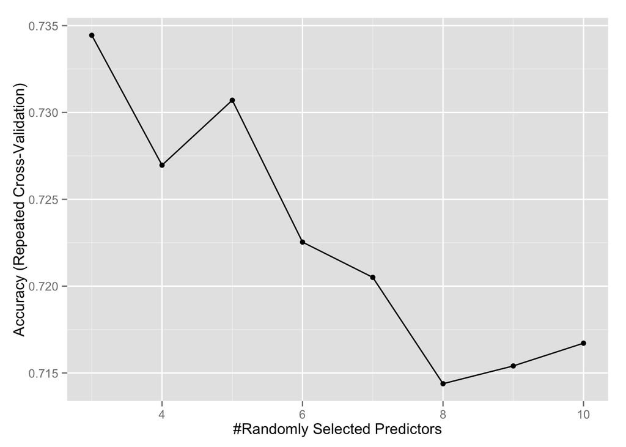

```r
ggplot(rf_model)
```

```r
rf_testing_y <- predict(rf_model, newdata = wle_testing)
rf_cf <- confusionMatrix(rf_testing_y, wle_testing_y)
```

Result of the best model on testing dataset:

Contingency table:

```
##           Reference
## Prediction  A  B  C  D  E
##          A 63 12  7  6  2
##          B  6 25  8  0  1
##          C  1  3 26  2  4
##          D  2  1  1 28  1
##          E  0  7  1  5 38
```

Overall Accuracy:

```
## Accuracy
##     0.72
```

### Stochastic Gradient Boosting

Stochastic Gradient Boosting method is applied in this section. The tuning parameter `interaction.depth` represents the maximum depth of variable interactions. 1 implies an additive model, 2 implies a model with up to 2-way interactions, etc. Here interaction.dapth ranges from `3` to `6` are chosen. The total number of trees `n.tree` are chosen to range from `30` to `900`, with `30` increment. A shrinkage parameter `shrinkage` with value `0.2` are applied to each tree in the expansion to prevent over-fitting problem.

```r
gbm_ctrl <- trainControl(method = "repeatedcv", number = 5, repeats = 5)
gbm_grid <- expand.grid(interaction.depth = c(3, 4, 5, 6), n.trees = 1:30*30, shrinkage = 0.2)
gbm_model <- train(wle_training, wle_training_y, method = "gbm", trControl = gbm_ctrl, tuneGrid = gbm_grid, metric = "Accuracy", verbose = FALSE)
```

After Training, show the best models in terms of accuracy in these 5 repeated 5-fold cross-validations.

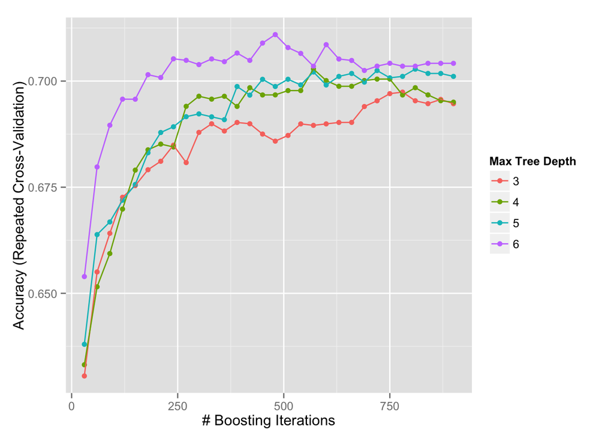

```r
ggplot(gbm_model)
```

```r
gbm_testing_y <- predict(gbm_model, newdata = wle_testing)
gbm_cf <- confusionMatrix(gbm_testing_y, wle_testing_y)
```

Result of the best model on testing dataset:

Contingency table:

```
##           Reference
## Prediction  A  B  C  D  E
##          A 56  5 11  7  2
##          B 13 27  3  1  5
##          C  2  3 26  1  3
##          D  1  0  1 26  3
##          E  0 13  2  6 33
```

Overall Accuracy:

```
## Accuracy
##    0.672
```

### Multi-class Logistic Regression with L1/L2 mixed Regularization

Generalized linear models via penalized maximum likelihood are applied in this section. Here I choose to use the `glmnet` package in `caret`. The tuning parameter `lambda` ranges from $10^{-3}$ to $10^{-1}$. The alpah value shows a mixture of L1 regularization (`lasso`, `alpha = 1`) and L2 regularization (`ridge`, `alpha = 0`) and elastic net mixture at `alpha = 0.5`.

```r
glmnet_ctrl <- trainControl(method = "repeatedcv", number = 5, repeats = 5)
glmnet_grid <- expand.grid(lambda = 10^(seq(-3,-1,0.1)), alpha = c(0.0, 0.5, 1.0))
glmnet_model <- train(wle_training, wle_training_y, method = "glmnet", trControl = glmnet_ctrl, tuneGrid = glmnet_grid, metric = "Accuracy", family = c("multinomial"))
```

After Training, show the best models in terms of accuracy in these 5 repeated 5-fold cross-validations.

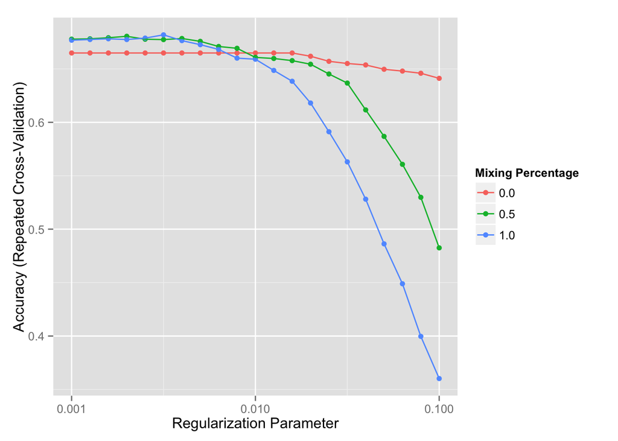

```r
ggplot(glmnet_model) + scale_x_log10()
```

```r
glmnet_testing_y <- predict(glmnet_model, newdata = wle_testing)
glmnet_cf <- confusionMatrix(glmnet_testing_y, wle_testing_y)
```

Result of the best model on testing dataset:

Contingency table:

```
##           Reference
## Prediction  A  B  C  D  E
##          A 50  3 12  5  2
##          B 10 30  3  0  6
##          C  7  8 24  7  5
##          D  4  3  4 26  9
##          E  1  4  0  3 24
```

Overall Accuracy:

```
## Accuracy
##    0.616
```

## Summary

Three different machine learning models are compared. In this particular dataset, random forest model yiels the best prediction accuracy. The prediction parameters must be carefully tuned using cross-validation method. We might need more complicated model to improve prediction accuracy.